# DSI_Data_Challenge

# Figure 4

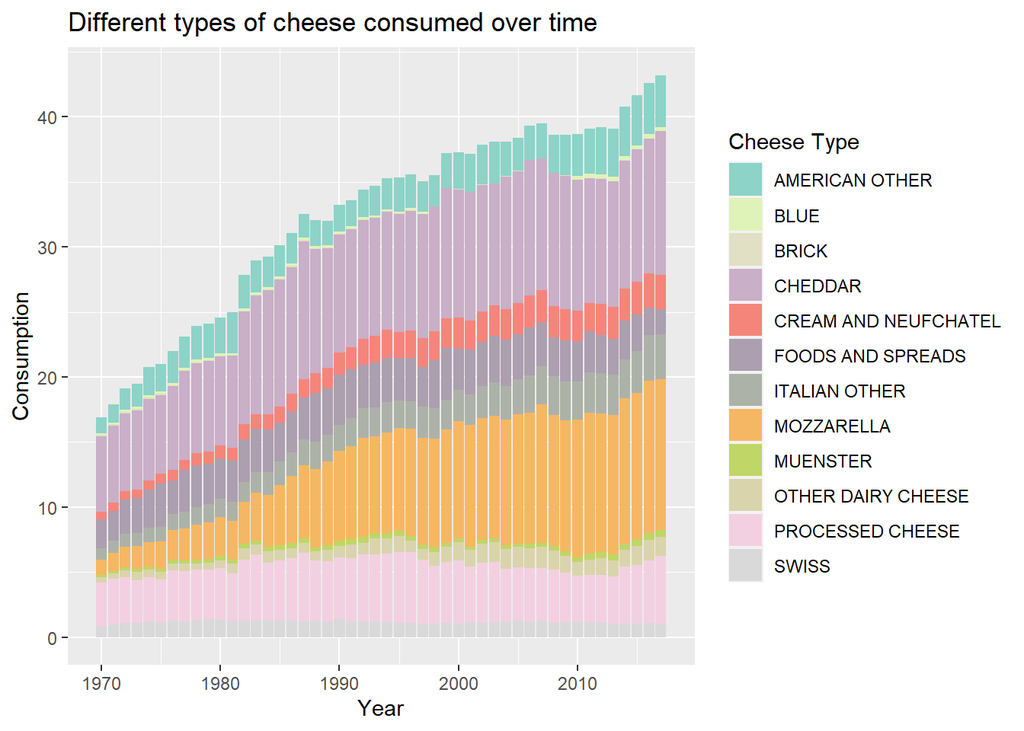

```r
clean_cheese_updated <- clean_cheese %>%
  select(0:13) %>% ## remove all the total cheese variables we do not want.
  pivot_longer(!Year, names_to = "cheese_type", values_to = "consumption") ## pivot_longer() "lengthens" data by increasing the number of rows and decreasing the number of columns

clean_cheese_updated$cheese_type <- toupper(clean_cheese_updated$cheese_type) ## capitalize all the names of cheese type

colourCount = length(unique(clean_cheese_updated$cheese_type)) ## count how many cheese types there are
getPalette = colorRampPalette(brewer.pal(n = 9, "Set3")) ## This is for using RColorBrewer; this will generate 100 colors based on the 9 from the ‘Set3’ palette

## initiate ggplot for plotting graphs
## using geom_bar() to create a bar plot
## x,y axes and main title will be labeled with labs()
ggplot(clean_cheese_updated,
       aes(x = Year,
           y = consumption,
           fill = cheese_type)) +
  geom_bar(position = "stack",
           stat = "identity") + ## plot a stacked bar plot so position = 'stack'
  labs(x ='Year',
       y ='Consumption',
       title ='Different types of cheese consumed over time') +
  scale_fill_manual(values = getPalette(colourCount),
                    name = 'Cheese Type') ## this allows R to specify the set of mappings from levels in the data to aesthetic values
```

# Figure 5

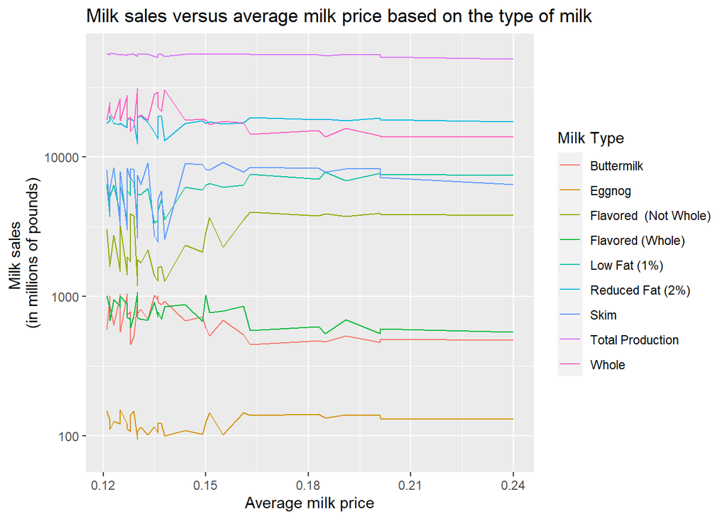

```r
new_data <-left_join(fluid_milk_sales, milkcow_facts, by = c('year'='year')) ## join two data.tables together
## character vector of variables to join by is 'year' in both data tables.

## initiate ggplot for plotting graphs
## geom_line() connects points in order of the variable on the x axis to create a line plot
## x,y axes and main title will be labeled with labs()
ggplot(new_data, aes(x = avg_price_milk,
                     y = pounds / 1000000)) + ## supply a dataset and aesthetic mapping by x and y.
  geom_line(aes(color = milk_type)) + ## plot the line graph by connecting observations, colored by different milk type.
  labs(x ='Average milk price',
       y ='Milk sales \n(in millions of pounds)',
       title ='Milk sales versus average milk price based on the type of milk') +
  scale_y_continuous(trans ='log10') +
  guides(color = guide_legend(title ='Milk Type')) ## legend will be set and renamed guide_legend()
```

Figure 5. We can see from the graph, if we plot milk sales against average milk price, we can see almost all the milk types fluctuate when average milk price increases from 0.12 to 0.165, then milk sales remain stable even when average milk price increases after price = 0.165. However, even there is fluctuation of milk sales when average milk price is low, overall, milk sales of each milk type does not change much when average milk price increases. In conclusion, milk sales for each milk type is irrelevant to change in average milk price.